# Home Credit Loan Default Prediction - Phase 3

### **6.1.2 Stacking**

```python
from sklearn.ensemble import StackingClassifier

meta_model = Pipeline([
    ('LogisticRegression', LogisticRegression(random_state=42))
])

stacking_models = {
    "DecisionTree": DecisionTreeClassifier(random_state=42),
    "RandomForest": RandomForestClassifier(random_state=42),
}
```

```python
stacking_estimators = [
    (name, Pipeline([
        ('preprocessor', preprocessor),
        ('model', pipeline)
    ]))
    for name, pipeline in stacking_models.items()
]
stacking_clf = StackingClassifier(
    estimators=stacking_estimators,
    final_estimator=meta_model
)
```

```python
%%time
stacking_clf.fit(X_train, y_train)
```

```
CPU times: user 19min 54s, sys: 7.5 s, total: 20min 1s
Wall time: 19min 55s
```

```
StackingClassifier(estimators=[('DecisionTree',
                                Pipeline(steps=[('preprocessor',
                                                 ColumnTransformer(transformers=[('num',
                                                                                  Pipeline(steps=[('imputer',
                                                                                                   SimpleImputer()),
                                                                                                  ('scaler',
                                                                                                   StandardScaler())]),
                                                                                  ['SK_ID_CURR',
                                                                                   'CNT_CHILDREN',
                                                                                   'AMT_INCOME_TOTAL',
                                                                                   'AMT_CREDIT',
                                                                                   'AMT_ANNUITY',
                                                                                   'AMT_GOODS_PRICE',
                                                                                   'REGION_POPULATION_RELATIVE',
                                                                                   'DAYS_BIRTH',
                                                                                   'DAYS_EMPLOYED',
                                                                                   'DAYS_R...
                                                                                   'NAME_EDUCATION_TYPE',
                                                                                   'NAME_FAMILY_STATUS',
                                                                                   'NAME_HOUSING_TYPE',
                                                                                   'OCCUPATION_TYPE',
                                                                                   'WEEKDAY_APPR_PROCESS_START',
                                                                                   'ORGANIZATION_TYPE',
                                                                                   'FONDKAPREMONT_MODE',
                                                                                   'HOUSETYPE_MODE',
                                                                                   'WALLSMATERIAL_MODE',
                                                                                   'EMERGENCYSTATE_MODE'])])),
                                                ('model',
                                                 RandomForestClassifier(random_state=42))]))],
                   final_estimator=Pipeline(steps=[('LogisticRegression',
                                                    LogisticRegression(random_state=42))]))
```

```python
y_pred_stacking = stacking_clf.predict(X_test)
```

```python
print("\nStacking Classifier Performance:")
print(f"Accuracy: {accuracy_score(y_test, y_pred_stacking):.4f}")
print(classification_report(y_test, y_pred_stacking))
```

```
Stacking Classifier Performance:
Accuracy: 0.9161
              precision    recall  f1-score   support

           0       0.92      1.00      0.96     35915
           1       0.52      0.02      0.04      3293

    accuracy                           0.92     39208
   macro avg       0.72      0.51      0.50     39208
weighted avg       0.88      0.92      0.88     39208
```

```python
populate_expLog(X_train, X_valid, X_test, "Stacking_ensemble",stacking_clf)
```

```python
expLog
```

|  | Experiment_Name | Train_Accuracy | Valid_Accuracy | Test_Accuracy | Train_ROC_AUC | Valid_ROC_AUC | Test_ROC_AUC | Train_Precision | Valid_Precision | Test_Precision | Train_Recall | Valid_Recall | Test_Recall | Train_F1 | Valid_F1 | Test_F1 | Train_Log_Loss | Valid_Log_Loss | Test_Log_Loss |
| --- | --- | --- | --- | --- | --- | --- | --- | --- | --- | --- | --- | --- | --- | --- | --- | --- | --- | --- | --- |
| 0 | LogisticRegression_208_features | 0.9197 | 0.9197 | 0.9160 | 0.7608 | 0.7537 | 0.7594 | 0.4870 | 0.5448 | 0.4955 | 0.0179 | 0.0196 | 0.0167 | 0.0345 | 0.0379 | 0.0323 | 0.2451 | 0.2478 | 0.2540 |
| 1 | DecisionTree_208_features | 1.0000 | 0.8546 | 0.8499 | 1.0000 | 0.5443 | 0.5416 | 1.0000 | 0.1511 | 0.1515 | 1.0000 | 0.1743 | 0.1710 | 1.0000 | 0.1619 | 0.1606 | 0.0000 | 5.2424 | 5.4091 |
| 2 | RandomForest_208_features | 1.0000 | 0.9195 | 0.9162 | 1.0000 | 0.7212 | 0.7237 | 1.0000 | 0.7500 | 0.9000 | 0.9998 | 0.0024 | 0.0027 | 0.9999 | 0.0048 | 0.0054 | 0.0600 | 0.2772 | 0.2828 |
| 3 | GradientBoosting_208_features | 0.9208 | 0.9198 | 0.9162 | 0.7784 | 0.7656 | 0.7678 | 0.6870 | 0.5645 | 0.5357 | 0.0228 | 0.0188 | 0.0182 | 0.0441 | 0.0364 | 0.0352 | 0.2394 | 0.2437 | 0.2518 |
| 4 | XGBoosting_208_features | 0.9291 | 0.9192 | 0.9149 | 0.8847 | 0.7647 | 0.7688 | 0.8561 | 0.4910 | 0.4357 | 0.1395 | 0.0584 | 0.0452 | 0.2400 | 0.1044 | 0.0820 | 0.1940 | 0.2448 | 0.2523 |
| 5 | LightGradientBoosting_208_features | 0.9225 | 0.9204 | 0.9165 | 0.8249 | 0.7743 | 0.7739 | 0.7655 | 0.5966 | 0.5538 | 0.0491 | 0.0374 | 0.0313 | 0.0923 | 0.0704 | 0.0592 | 0.2229 | 0.2404 | 0.2491 |
| 6 | LightGradientBoosting_208_features | 0.9340 | 0.9199 | 0.9163 | 0.9994 | 0.7538 | 0.7554 | 1.0000 | 0.5660 | 0.5385 | 0.1765 | 0.0242 | 0.0234 | 0.3000 | 0.0464 | 0.0448 | 0.1231 | 0.2491 | 0.2571 |
| 7 | LightGradientBoosting_208_features | 1.0000 | 0.9198 | 0.9161 | 1.0000 | 0.7213 | 0.7235 | 1.0000 | 0.5450 | 0.5177 | 1.0000 | 0.0293 | 0.0222 | 1.0000 | 0.0557 | 0.0425 | 0.0426 | 0.2544 | 0.2626 |

## 6.2 Model testing - no hyper parameter tuning (post-Feature Selection)

```python
models_PCA = {
    #"SVC": SVC(probability=True, random_state=42), #adding in SVC now that we've reduced our features
    "LogisticRegression": LogisticRegression(random_state=42),
    "DecisionTree": DecisionTreeClassifier(random_state=42),
    "RandomForest": RandomForestClassifier(random_state=42),
    "GradientBoosting": GradientBoostingClassifier(random_state=42),
    "XGBoosting": XGBClassifier(random_state=42),
    "LightGradientBoosting": LGBMClassifier(random_state=42)
}
```

```python
pipelines_PCA = {}
for model_name, model in models_PCA.items():
    pipelines_PCA[model_name] = Pipeline(steps=[
        ('model', model)
    ])
```

```python
%%time
best_models_PCA = {}
for model_name, pipeline in pipelines_PCA.items():
    print(f"Training {model_name}...")
    pipeline.fit(X_train_reduced, y_train)
    best_models_PCA[model_name] = pipeline
```

```
Training LogisticRegression...
Training DecisionTree...
Training RandomForest...
Training GradientBoosting...
Training XGBoosting...
Training LightGradientBoosting...
[LightGBM] [Info] Number of positive: 17815, number of negative: 204361
[LightGBM] [Info] Auto-choosing row-wise multi-threading, the overhead of testing was 0.002839 seconds.
You can set `force_row_wise=true` to remove the overhead.
And if memory is not enough, you can set `force_col_wise=true`.
[LightGBM] [Info] Total Bins 4869
[LightGBM] [Info] Number of data points in the train set: 222176, number of used features: 20
[LightGBM] [Info] [binary:BoostFromScore]: pavg=0.080184 -> initscore=-2.439847
[LightGBM] [Info] Start training from score -2.439847
CPU times: user 4min 43s, sys: 1.5 s, total: 4min 44s
Wall time: 4min 33s
```

```python
for model_name, model in best_models_PCA.items():
    y_pred = model.predict(X_test_reduced)
    print(f"\n{model_name} Performance:")
    print(f"Accuracy: {accuracy_score(y_test, y_pred):.4f}")
    print(classification_report(y_test, y_pred))
    populate_expLog(X_train_reduced, X_valid_reduced, X_test_reduced, model_name, model)

expLog
```

```
LogisticRegression Performance:
Accuracy: 0.9160
              precision    recall  f1-score   support

           0       0.92      1.00      0.96     35915
           1       0.47      0.01      0.01      3293

    accuracy                           0.92     39208
   macro avg       0.70      0.50      0.48     39208
weighted avg       0.88      0.92      0.88     39208


DecisionTree Performance:
Accuracy: 0.8497
              precision    recall  f1-score   support

           0       0.92      0.91      0.92     35915
           1       0.14      0.16      0.15      3293

    accuracy                           0.85     39208
   macro avg       0.53      0.53      0.53     39208
weighted avg       0.86      0.85      0.85     39208


RandomForest Performance:
Accuracy: 0.9160
              precision    recall  f1-score   support

           0       0.92      1.00      0.96     35915
           1       0.52      0.00      0.01      3293

    accuracy                           0.92     39208
   macro avg       0.72      0.50      0.48     39208
weighted avg       0.88      0.92      0.88     39208


GradientBoosting Performance:
Accuracy: 0.9160
              precision    recall  f1-score   support

```

[output cut: 15 more lines]

```
    accuracy                           0.92     39208
   macro avg       0.67      0.51      0.50     39208
weighted avg       0.88      0.92      0.88     39208


LightGradientBoosting Performance:
Accuracy: 0.9159
              precision    recall  f1-score   support

           0       0.92      1.00      0.96     35915
           1       0.47      0.01      0.02      3293

    accuracy                           0.92     39208
   macro avg       0.69      0.50      0.49     39208
weighted avg       0.88      0.92      0.88     39208
```

|  | Experiment_Name | Train_Accuracy | Valid_Accuracy | Test_Accuracy | Train_ROC_AUC | Valid_ROC_AUC | Test_ROC_AUC | Train_Precision | Valid_Precision | Test_Precision | Train_Recall | Valid_Recall | Test_Recall | Train_F1 | Valid_F1 | Test_F1 | Train_Log_Loss | Valid_Log_Loss | Test_Log_Loss |
| --- | --- | --- | --- | --- | --- | --- | --- | --- | --- | --- | --- | --- | --- | --- | --- | --- | --- | --- | --- |
| 0 | LogisticRegression_208_features | 0.9197 | 0.9197 | 0.9160 | 0.7608 | 0.7537 | 0.7594 | 0.4870 | 0.5448 | 0.4955 | 0.0179 | 0.0196 | 0.0167 | 0.0345 | 0.0379 | 0.0323 | 0.2451 | 0.2478 | 0.2540 |
| 1 | DecisionTree_208_features | 1.0000 | 0.8546 | 0.8499 | 1.0000 | 0.5443 | 0.5416 | 1.0000 | 0.1511 | 0.1515 | 1.0000 | 0.1743 | 0.1710 | 1.0000 | 0.1619 | 0.1606 | 0.0000 | 5.2424 | 5.4091 |
| 2 | RandomForest_208_features | 1.0000 | 0.9195 | 0.9162 | 1.0000 | 0.7212 | 0.7237 | 1.0000 | 0.7500 | 0.9000 | 0.9998 | 0.0024 | 0.0027 | 0.9999 | 0.0048 | 0.0054 | 0.0600 | 0.2772 | 0.2828 |
| 3 | GradientBoosting_208_features | 0.9208 | 0.9198 | 0.9162 | 0.7784 | 0.7656 | 0.7678 | 0.6870 | 0.5645 | 0.5357 | 0.0228 | 0.0188 | 0.0182 | 0.0441 | 0.0364 | 0.0352 | 0.2394 | 0.2437 | 0.2518 |
| 4 | XGBoosting_208_features | 0.9291 | 0.9192 | 0.9149 | 0.8847 | 0.7647 | 0.7688 | 0.8561 | 0.4910 | 0.4357 | 0.1395 | 0.0584 | 0.0452 | 0.2400 | 0.1044 | 0.0820 | 0.1940 | 0.2448 | 0.2523 |
| 5 | LightGradientBoosting_208_features | 0.9225 | 0.9204 | 0.9165 | 0.8249 | 0.7743 | 0.7739 | 0.7655 | 0.5966 | 0.5538 | 0.0491 | 0.0374 | 0.0313 | 0.0923 | 0.0704 | 0.0592 | 0.2229 | 0.2404 | 0.2491 |
| 6 | LightGradientBoosting_208_features | 0.9340 | 0.9199 | 0.9163 | 0.9994 | 0.7538 | 0.7554 | 1.0000 | 0.5660 | 0.5385 | 0.1765 | 0.0242 | 0.0234 | 0.3000 | 0.0464 | 0.0448 | 0.1231 | 0.2491 | 0.2571 |
| 7 | LightGradientBoosting_208_features | 1.0000 | 0.9198 | 0.9161 | 1.0000 | 0.7213 | 0.7235 | 1.0000 | 0.5450 | 0.5177 | 1.0000 | 0.0293 | 0.0222 | 1.0000 | 0.0557 | 0.0425 | 0.0426 | 0.2544 | 0.2626 |
| 8 | LogisticRegression_20_features | 0.9197 | 0.9193 | 0.9160 | 0.7266 | 0.7263 | 0.7257 | 0.4467 | 0.4375 | 0.4737 | 0.0049 | 0.0038 | 0.0055 | 0.0098 | 0.0075 | 0.0108 | 0.2540 | 0.2553 | 0.2626 |
| 9 | DecisionTree_20_features | 1.0000 | 0.8542 | 0.8497 | 1.0000 | 0.5401 | 0.5344 | 1.0000 | 0.1452 | 0.1413 | 1.0000 | 0.1657 | 0.1555 | 1.0000 | 0.1548 | 0.1481 | 0.0000 | 5.2557 | 5.4165 |
| 10 | RandomForest_20_features | 1.0000 | 0.9193 | 0.9160 | 1.0000 | 0.7147 | 0.7104 | 1.0000 | 0.4500 | 0.5217 | 0.9995 | 0.0048 | 0.0036 | 0.9997 | 0.0096 | 0.0072 | 0.0598 | 0.2840 | 0.2861 |
| 11 | GradientBoosting_20_features | 0.9204 | 0.9196 | 0.9160 | 0.7552 | 0.7450 | 0.7474 | 0.6704 | 0.5455 | 0.4833 | 0.0136 | 0.0113 | 0.0088 | 0.0266 | 0.0221 | 0.0173 | 0.2462 | 0.2495 | 0.2574 |
| 12 | XGBoosting_20_features | 0.9256 | 0.9189 | 0.9151 | 0.8621 | 0.7421 | 0.7394 | 0.8825 | 0.4552 | 0.4167 | 0.0831 | 0.0328 | 0.0273 | 0.1519 | 0.0612 | 0.0513 | 0.2076 | 0.2517 | 0.2608 |
| 13 | LightGradientBoosting_20_features | 0.9209 | 0.9194 | 0.9159 | 0.7957 | 0.7483 | 0.7498 | 0.7905 | 0.4835 | 0.4667 | 0.0186 | 0.0118 | 0.0085 | 0.0364 | 0.0231 | 0.0167 | 0.2340 | 0.2483 | 0.2565 |

## 6.3 Ensemble models - Reduced Data Set

We again trained our two classifiers but this time on the reduced data set.

### **6.3.1 Voting**

```python
best_models = {
    #"SVC": SVC(probability=True, random_state=42), #excluding due to a lack of processing resources required to process this model
    "LogisticRegression": LogisticRegression(random_state=42),
    "DecisionTree": DecisionTreeClassifier(random_state=42),
    "RandomForest": RandomForestClassifier(random_state=42),
    "GradientBoosting": GradientBoostingClassifier(random_state=42),
    "XGBoosting": XGBClassifier(random_state=42),
    "LightGradientBoosting": LGBMClassifier(random_state=42)
}

categorical_features = X_train_reduced.select_dtypes(include=['object', 'category']).columns.tolist()
numerical_features = X_train_reduced.select_dtypes(include=['int64', 'float64']).columns.tolist()

categorical_transformer = Pipeline(steps=[
    ('target_encoder', TargetEncoder(handle_unknown='ignore'))
])

numerical_transformer = Pipeline(steps=[
    ('imputer', SimpleImputer(strategy='mean')),
    ('scaler', StandardScaler())
])

voting_preprocessor = ColumnTransformer(
    transformers=[
        ('num', numerical_transformer, numerical_features),
        ('cat', categorical_transformer, categorical_features)
    ]
)

voting_pipelines = {}
for model_name, model in models.items():
    voting_pipelines[model_name] = Pipeline(steps=[
        ('preprocessor', voting_preprocessor),
        ('model', model)
    ])

voting_estimators = [
    (name, Pipeline([
        ('preprocessor', voting_preprocessor),
        ('model', pipeline)
    ]))
    for name, pipeline in best_models.items()
]
```

```python
voting_clf = VotingClassifier(estimators=voting_estimators, voting='soft')
```

```python
%%time
voting_clf.fit(X_train_reduced, y_train)
```

```
[LightGBM] [Info] Number of positive: 17815, number of negative: 204361
[LightGBM] [Info] Auto-choosing row-wise multi-threading, the overhead of testing was 0.002802 seconds.
You can set `force_row_wise=true` to remove the overhead.
And if memory is not enough, you can set `force_col_wise=true`.
[LightGBM] [Info] Total Bins 4869
[LightGBM] [Info] Number of data points in the train set: 222176, number of used features: 20
[LightGBM] [Info] [binary:BoostFromScore]: pavg=0.080184 -> initscore=-2.439847
[LightGBM] [Info] Start training from score -2.439847
CPU times: user 4min 40s, sys: 1.51 s, total: 4min 41s
Wall time: 4min 31s
```

```
VotingClassifier(estimators=[('LogisticRegression',
                              Pipeline(steps=[('preprocessor',
                                               ColumnTransformer(transformers=[('num',
                                                                                Pipeline(steps=[('imputer',
                                                                                                 SimpleImputer()),
                                                                                                ('scaler',
                                                                                                 StandardScaler())]),
                                                                                ['num__payment_delay_days_max',
                                                                                 'num__DAYS_ID_PUBLISH',
                                                                                 'num__EXT_SOURCE_1',
                                                                                 'num__DAYS_EMPLOYED',
                                                                                 'num__POS_CNT_INSTALMENT_FUTURE_SUM',
                                                                                 'num__AMT_ANNUITY_min_...
                                                                                 'num__DAYS_REGISTRATION',
                                                                                 'num__DAYS_LAST_PHONE_CHANGE',
                                                                                 'num__AMT_ANNUITY',
                                                                                 'num__DAYS_BIRTH',
                                                                                 'num__SK_ID_CURR',
                                                                                 'num__payment_delay_days_mean',
                                                                                 'num__AMT_APPLICATION_mean',
                                                                                 'num__REGION_POPULATION_RELATIVE']),
                                                                               ('cat',
                                                                                Pipeline(steps=[('target_encoder',
                                                                                                 TargetEncoder(handle_unknown='ignore'))]),
                                                                                [])])),
                                              ('model',
                                               LGBMClassifier(random_state=42))]))],
                 voting='soft')
```

```python
y_pred_voting = voting_clf.predict(X_test_reduced)
```

```python
print("\nVoting Classifier Performance (with feature selection):")
print(f"Accuracy: {accuracy_score(y_test, y_pred_voting):.4f}")
print(classification_report(y_test, y_pred_voting))
```

```
Voting Classifier Performance (with feature selection):
Accuracy: 0.9156
              precision    recall  f1-score   support

           0       0.92      1.00      0.96     35915
           1       0.40      0.01      0.02      3293

    accuracy                           0.92     39208
   macro avg       0.66      0.50      0.49     39208
weighted avg       0.87      0.92      0.88     39208
```

```python
populate_expLog(X_train_reduced, X_valid_reduced, X_test_reduced, "Voting_ensemble",voting_clf)
```

```python
expLog
```

|  | Experiment_Name | Train_Accuracy | Valid_Accuracy | Test_Accuracy | Train_ROC_AUC | Valid_ROC_AUC | Test_ROC_AUC | Train_Precision | Valid_Precision | Test_Precision | Train_Recall | Valid_Recall | Test_Recall | Train_F1 | Valid_F1 | Test_F1 | Train_Log_Loss | Valid_Log_Loss | Test_Log_Loss |
| --- | --- | --- | --- | --- | --- | --- | --- | --- | --- | --- | --- | --- | --- | --- | --- | --- | --- | --- | --- |
| 0 | LogisticRegression_208_features | 0.9197 | 0.9197 | 0.9160 | 0.7608 | 0.7537 | 0.7594 | 0.4870 | 0.5448 | 0.4955 | 0.0179 | 0.0196 | 0.0167 | 0.0345 | 0.0379 | 0.0323 | 0.2451 | 0.2478 | 0.2540 |
| 1 | DecisionTree_208_features | 1.0000 | 0.8546 | 0.8499 | 1.0000 | 0.5443 | 0.5416 | 1.0000 | 0.1511 | 0.1515 | 1.0000 | 0.1743 | 0.1710 | 1.0000 | 0.1619 | 0.1606 | 0.0000 | 5.2424 | 5.4091 |
| 2 | RandomForest_208_features | 1.0000 | 0.9195 | 0.9162 | 1.0000 | 0.7212 | 0.7237 | 1.0000 | 0.7500 | 0.9000 | 0.9998 | 0.0024 | 0.0027 | 0.9999 | 0.0048 | 0.0054 | 0.0600 | 0.2772 | 0.2828 |
| 3 | GradientBoosting_208_features | 0.9208 | 0.9198 | 0.9162 | 0.7784 | 0.7656 | 0.7678 | 0.6870 | 0.5645 | 0.5357 | 0.0228 | 0.0188 | 0.0182 | 0.0441 | 0.0364 | 0.0352 | 0.2394 | 0.2437 | 0.2518 |
| 4 | XGBoosting_208_features | 0.9291 | 0.9192 | 0.9149 | 0.8847 | 0.7647 | 0.7688 | 0.8561 | 0.4910 | 0.4357 | 0.1395 | 0.0584 | 0.0452 | 0.2400 | 0.1044 | 0.0820 | 0.1940 | 0.2448 | 0.2523 |
| 5 | LightGradientBoosting_208_features | 0.9225 | 0.9204 | 0.9165 | 0.8249 | 0.7743 | 0.7739 | 0.7655 | 0.5966 | 0.5538 | 0.0491 | 0.0374 | 0.0313 | 0.0923 | 0.0704 | 0.0592 | 0.2229 | 0.2404 | 0.2491 |
| 6 | LightGradientBoosting_208_features | 0.9340 | 0.9199 | 0.9163 | 0.9994 | 0.7538 | 0.7554 | 1.0000 | 0.5660 | 0.5385 | 0.1765 | 0.0242 | 0.0234 | 0.3000 | 0.0464 | 0.0448 | 0.1231 | 0.2491 | 0.2571 |
| 7 | LightGradientBoosting_208_features | 1.0000 | 0.9198 | 0.9161 | 1.0000 | 0.7213 | 0.7235 | 1.0000 | 0.5450 | 0.5177 | 1.0000 | 0.0293 | 0.0222 | 1.0000 | 0.0557 | 0.0425 | 0.0426 | 0.2544 | 0.2626 |
| 8 | LogisticRegression_20_features | 0.9197 | 0.9193 | 0.9160 | 0.7266 | 0.7263 | 0.7257 | 0.4467 | 0.4375 | 0.4737 | 0.0049 | 0.0038 | 0.0055 | 0.0098 | 0.0075 | 0.0108 | 0.2540 | 0.2553 | 0.2626 |
| 9 | DecisionTree_20_features | 1.0000 | 0.8542 | 0.8497 | 1.0000 | 0.5401 | 0.5344 | 1.0000 | 0.1452 | 0.1413 | 1.0000 | 0.1657 | 0.1555 | 1.0000 | 0.1548 | 0.1481 | 0.0000 | 5.2557 | 5.4165 |
| 10 | RandomForest_20_features | 1.0000 | 0.9193 | 0.9160 | 1.0000 | 0.7147 | 0.7104 | 1.0000 | 0.4500 | 0.5217 | 0.9995 | 0.0048 | 0.0036 | 0.9997 | 0.0096 | 0.0072 | 0.0598 | 0.2840 | 0.2861 |
| 11 | GradientBoosting_20_features | 0.9204 | 0.9196 | 0.9160 | 0.7552 | 0.7450 | 0.7474 | 0.6704 | 0.5455 | 0.4833 | 0.0136 | 0.0113 | 0.0088 | 0.0266 | 0.0221 | 0.0173 | 0.2462 | 0.2495 | 0.2574 |
| 12 | XGBoosting_20_features | 0.9256 | 0.9189 | 0.9151 | 0.8621 | 0.7421 | 0.7394 | 0.8825 | 0.4552 | 0.4167 | 0.0831 | 0.0328 | 0.0273 | 0.1519 | 0.0612 | 0.0513 | 0.2076 | 0.2517 | 0.2608 |
| 13 | LightGradientBoosting_20_features | 0.9209 | 0.9194 | 0.9159 | 0.7957 | 0.7483 | 0.7498 | 0.7905 | 0.4835 | 0.4667 | 0.0186 | 0.0118 | 0.0085 | 0.0364 | 0.0231 | 0.0167 | 0.2340 | 0.2483 | 0.2565 |
| 14 | LightGradientBoosting_20_features | 0.9294 | 0.9194 | 0.9156 | 0.9996 | 0.7316 | 0.7315 | 1.0000 | 0.4957 | 0.4024 | 0.1193 | 0.0156 | 0.0100 | 0.2131 | 0.0303 | 0.0196 | 0.1274 | 0.2559 | 0.2646 |

### **6.3.2 Stacking**

```python
from sklearn.ensemble import StackingClassifier

meta_model = Pipeline([
    ('LogisticRegression', LogisticRegression(random_state=42))
])

stacking_models = {
    "DecisionTree": DecisionTreeClassifier(random_state=42),
    "RandomForest": RandomForestClassifier(random_state=42),
}
```

```python
stacking_preprocessor = ColumnTransformer(
    transformers=[
        ('num', numerical_transformer, numerical_features),
        ('cat', categorical_transformer, categorical_features)
    ]
)
```

```python
stacking_estimators = [
    (name, Pipeline([
        ('preprocessor', stacking_preprocessor),
        ('model', pipeline)
    ]))
    for name, pipeline in stacking_models.items()
]
stacking_clf = StackingClassifier(
    estimators=stacking_estimators,
    final_estimator=meta_model
)
```

```python
%%time
stacking_clf.fit(X_train_reduced, y_train)
```

```
CPU times: user 10min 55s, sys: 1.46 s, total: 10min 56s
Wall time: 10min 53s
```

```
StackingClassifier(estimators=[('DecisionTree',
                                Pipeline(steps=[('preprocessor',
                                                 ColumnTransformer(transformers=[('num',
                                                                                  Pipeline(steps=[('imputer',
                                                                                                   SimpleImputer()),
                                                                                                  ('scaler',
                                                                                                   StandardScaler())]),
                                                                                  ['num__payment_delay_days_max',
                                                                                   'num__DAYS_ID_PUBLISH',
                                                                                   'num__EXT_SOURCE_1',
                                                                                   'num__DAYS_EMPLOYED',
                                                                                   'num__POS_CNT_INSTALMENT_FUTURE_SUM',
                                                                                   'num__AMT_ANNUITY_min_y',
                                                                                   '...
                                                                                   'num__SK_ID_CURR',
                                                                                   'num__payment_delay_days_mean',
                                                                                   'num__AMT_APPLICATION_mean',
                                                                                   'num__REGION_POPULATION_RELATIVE']),
                                                                                 ('cat',
                                                                                  Pipeline(steps=[('target_encoder',
                                                                                                   TargetEncoder(handle_unknown='ignore'))]),
                                                                                  [])])),
                                                ('model',
                                                 RandomForestClassifier(random_state=42))]))],
                   final_estimator=Pipeline(steps=[('LogisticRegression',
                                                    LogisticRegression(random_state=42))]))
```

```python
y_pred_stacking = stacking_clf.predict(X_test_reduced)
```

```python
print("\nStacking Classifier Performance:")
print(f"Accuracy: {accuracy_score(y_test, y_pred_stacking):.4f}")
print(classification_report(y_test, y_pred_stacking))
```

```
Stacking Classifier Performance:
Accuracy: 0.9149
              precision    recall  f1-score   support

           0       0.92      1.00      0.96     35915
           1       0.36      0.02      0.03      3293

    accuracy                           0.91     39208
   macro avg       0.64      0.51      0.50     39208
weighted avg       0.87      0.91      0.88     39208
```

```python
populate_expLog(X_train_reduced, X_valid_reduced, X_test_reduced, "Stacking_ensemble",stacking_clf)
```

```python
expLog
```

|  | Experiment_Name | Train_Accuracy | Valid_Accuracy | Test_Accuracy | Train_ROC_AUC | Valid_ROC_AUC | Test_ROC_AUC | Train_Precision | Valid_Precision | Test_Precision | Train_Recall | Valid_Recall | Test_Recall | Train_F1 | Valid_F1 | Test_F1 | Train_Log_Loss | Valid_Log_Loss | Test_Log_Loss |
| --- | --- | --- | --- | --- | --- | --- | --- | --- | --- | --- | --- | --- | --- | --- | --- | --- | --- | --- | --- |
| 0 | LogisticRegression_208_features | 0.9197 | 0.9197 | 0.9160 | 0.7608 | 0.7537 | 0.7594 | 0.4870 | 0.5448 | 0.4955 | 0.0179 | 0.0196 | 0.0167 | 0.0345 | 0.0379 | 0.0323 | 0.2451 | 0.2478 | 0.2540 |
| 1 | DecisionTree_208_features | 1.0000 | 0.8546 | 0.8499 | 1.0000 | 0.5443 | 0.5416 | 1.0000 | 0.1511 | 0.1515 | 1.0000 | 0.1743 | 0.1710 | 1.0000 | 0.1619 | 0.1606 | 0.0000 | 5.2424 | 5.4091 |
| 2 | RandomForest_208_features | 1.0000 | 0.9195 | 0.9162 | 1.0000 | 0.7212 | 0.7237 | 1.0000 | 0.7500 | 0.9000 | 0.9998 | 0.0024 | 0.0027 | 0.9999 | 0.0048 | 0.0054 | 0.0600 | 0.2772 | 0.2828 |
| 3 | GradientBoosting_208_features | 0.9208 | 0.9198 | 0.9162 | 0.7784 | 0.7656 | 0.7678 | 0.6870 | 0.5645 | 0.5357 | 0.0228 | 0.0188 | 0.0182 | 0.0441 | 0.0364 | 0.0352 | 0.2394 | 0.2437 | 0.2518 |
| 4 | XGBoosting_208_features | 0.9291 | 0.9192 | 0.9149 | 0.8847 | 0.7647 | 0.7688 | 0.8561 | 0.4910 | 0.4357 | 0.1395 | 0.0584 | 0.0452 | 0.2400 | 0.1044 | 0.0820 | 0.1940 | 0.2448 | 0.2523 |
| 5 | LightGradientBoosting_208_features | 0.9225 | 0.9204 | 0.9165 | 0.8249 | 0.7743 | 0.7739 | 0.7655 | 0.5966 | 0.5538 | 0.0491 | 0.0374 | 0.0313 | 0.0923 | 0.0704 | 0.0592 | 0.2229 | 0.2404 | 0.2491 |
| 6 | LightGradientBoosting_208_features | 0.9340 | 0.9199 | 0.9163 | 0.9994 | 0.7538 | 0.7554 | 1.0000 | 0.5660 | 0.5385 | 0.1765 | 0.0242 | 0.0234 | 0.3000 | 0.0464 | 0.0448 | 0.1231 | 0.2491 | 0.2571 |
| 7 | LightGradientBoosting_208_features | 1.0000 | 0.9198 | 0.9161 | 1.0000 | 0.7213 | 0.7235 | 1.0000 | 0.5450 | 0.5177 | 1.0000 | 0.0293 | 0.0222 | 1.0000 | 0.0557 | 0.0425 | 0.0426 | 0.2544 | 0.2626 |
| 8 | LogisticRegression_20_features | 0.9197 | 0.9193 | 0.9160 | 0.7266 | 0.7263 | 0.7257 | 0.4467 | 0.4375 | 0.4737 | 0.0049 | 0.0038 | 0.0055 | 0.0098 | 0.0075 | 0.0108 | 0.2540 | 0.2553 | 0.2626 |
| 9 | DecisionTree_20_features | 1.0000 | 0.8542 | 0.8497 | 1.0000 | 0.5401 | 0.5344 | 1.0000 | 0.1452 | 0.1413 | 1.0000 | 0.1657 | 0.1555 | 1.0000 | 0.1548 | 0.1481 | 0.0000 | 5.2557 | 5.4165 |
| 10 | RandomForest_20_features | 1.0000 | 0.9193 | 0.9160 | 1.0000 | 0.7147 | 0.7104 | 1.0000 | 0.4500 | 0.5217 | 0.9995 | 0.0048 | 0.0036 | 0.9997 | 0.0096 | 0.0072 | 0.0598 | 0.2840 | 0.2861 |
| 11 | GradientBoosting_20_features | 0.9204 | 0.9196 | 0.9160 | 0.7552 | 0.7450 | 0.7474 | 0.6704 | 0.5455 | 0.4833 | 0.0136 | 0.0113 | 0.0088 | 0.0266 | 0.0221 | 0.0173 | 0.2462 | 0.2495 | 0.2574 |
| 12 | XGBoosting_20_features | 0.9256 | 0.9189 | 0.9151 | 0.8621 | 0.7421 | 0.7394 | 0.8825 | 0.4552 | 0.4167 | 0.0831 | 0.0328 | 0.0273 | 0.1519 | 0.0612 | 0.0513 | 0.2076 | 0.2517 | 0.2608 |
| 13 | LightGradientBoosting_20_features | 0.9209 | 0.9194 | 0.9159 | 0.7957 | 0.7483 | 0.7498 | 0.7905 | 0.4835 | 0.4667 | 0.0186 | 0.0118 | 0.0085 | 0.0364 | 0.0231 | 0.0167 | 0.2340 | 0.2483 | 0.2565 |
| 14 | LightGradientBoosting_20_features | 0.9294 | 0.9194 | 0.9156 | 0.9996 | 0.7316 | 0.7315 | 1.0000 | 0.4957 | 0.4024 | 0.1193 | 0.0156 | 0.0100 | 0.2131 | 0.0303 | 0.0196 | 0.1274 | 0.2559 | 0.2646 |
| 15 | LightGradientBoosting_20_features | 1.0000 | 0.9191 | 0.9149 | 1.0000 | 0.7148 | 0.7104 | 1.0000 | 0.4565 | 0.3636 | 1.0000 | 0.0226 | 0.0182 | 1.0000 | 0.0431 | 0.0347 | 0.0516 | 0.2572 | 0.2669 |

## 6.4 SVC model with PCA features using 20% of the training data

```python
## Reduced training dataset to 20% of its prior size
X_train_reduced_SVC, X_unused, y_train_reduced_SVC, y_unused = train_test_split(X_train_reduced, y_train, test_size=0.8, random_state=42)
```

```python
X_train_reduced_SVC = X_train_reduced_SVC.reset_index(drop=True)
y_train_reduced_SVC = y_train_reduced_SVC.reset_index(drop=True)
```

```python
reduced_SVC_pipeline = Pipeline([
    ('target_encoder', TargetEncoder(handle_unknown='ignore')),
    ('imputer', SimpleImputer(strategy='mean')),
    ('SVC', SVC(random_state=42, probability=True))
])
```

```python
%%time
reduced_SVC_pipeline.fit(X_train_reduced_SVC, y_train_reduced_SVC)
```

```
Pipeline(steps=[('target_encoder',
                 TargetEncoder(cols=[], handle_unknown='ignore')),
                ('imputer', SimpleImputer()),
                ('SVC', SVC(probability=True, random_state=42))])
```

```python
y_pred_reduced_SVC = reduced_SVC_pipeline.predict(X_test_reduced)
```

```python
print("\nSVC with 20% of training data Performance:")
print(f"Accuracy: {accuracy_score(y_test, y_pred_reduced_SVC):.4f}")
print(classification_report(y_test, y_pred_reduced_SVC))
```

```
SVC with 20% of training data Performance:
Accuracy: 0.9160
              precision    recall  f1-score   support

           0       0.92      1.00      0.96     35915
           1       0.00      0.00      0.00      3293

    accuracy                           0.92     39208
   macro avg       0.46      0.50      0.48     39208
weighted avg       0.84      0.92      0.88     39208
```

```python
# exp_name = f"SVC_20%_{X_train_reduced_SVC.shape[1]}_features"
# expLog.loc[len(expLog)] = [f"{exp_name}"] + list(np.round(
#                [accuracy_score(y_train_reduced_SVC, reduced_SVC_pipeline.predict(X_train_reduced_SVC)),
#                 accuracy_score(y_valid, reduced_SVC_pipeline.predict(X_valid_reduced)),
#                 accuracy_score(y_test, reduced_SVC_pipeline.predict(X_test_reduced)),
#                 roc_auc_score(y_train_reduced_SVC, reduced_SVC_pipeline.predict_proba(X_train_reduced_SVC)[:, 1]),
#                 roc_auc_score(y_valid, reduced_SVC_pipeline.predict_proba(X_valid_reduced)[:, 1]),
#                 roc_auc_score(y_test, reduced_SVC_pipeline.predict_proba(X_test_reduced)[:, 1]),
#                 precision_score(y_train_reduced_SVC, reduced_SVC_pipeline.predict(X_train_reduced_SVC)),
#                 precision_score(y_valid, reduced_SVC_pipeline.predict(X_valid_reduced)),
#                 precision_score(y_test, reduced_SVC_pipeline.predict(X_test_reduced)),
#                 recall_score(y_train_reduced_SVC, reduced_SVC_pipeline.predict(X_train_reduced_SVC)),
#                 recall_score(y_valid, reduced_SVC_pipeline.predict(X_valid_reduced)),
#                 recall_score(y_test, reduced_SVC_pipeline.predict(X_test_reduced)),
#                 f1_score(y_train_reduced_SVC, reduced_SVC_pipeline.predict(X_train_reduced_SVC)),
#                 f1_score(y_valid, reduced_SVC_pipeline.predict(X_valid_reduced)),
#                 f1_score(y_test, reduced_SVC_pipeline.predict(X_test_reduced)),
#                 log_loss(y_train_reduced_SVC, reduced_SVC_pipeline.predict_proba(X_train_reduced_SVC)[:, 1]),
#                 log_loss(y_valid, reduced_SVC_pipeline.predict_proba(X_valid_reduced)[:, 1]),
#                 log_loss(y_test, reduced_SVC_pipeline.predict_proba(X_test_reduced)[:, 1])],

#     4))
expLog
```

[output not shown]

```python
expLog = expLog.drop(expLog.index[expLog.index==7])
expLog
```

[output not shown]

[figure not shown]

```python
# Metrics to plot
metrics_to_plot = ["Valid_F1", "Test_ROC_AUC", "Valid_Accuracy"]

# Create the plot
fig, ax = plt.subplots(figsize=(12, 6))

# X-axis positions for the models
x = np.arange(len(expLog["Experiment_Name"]))

# Bar width
width = 0.25

# Plot each metric
for i, metric in enumerate(metrics_to_plot):
    ax.bar(x + i * width, expLog[metric], width, label=metric)

# Add plot details
ax.set_xlabel("Models", fontsize=12)
ax.set_ylabel("Scores", fontsize=12)
ax.set_title("Key Metrics Comparison Across Models", fontsize=14)
ax.set_xticks(x + width)
ax.set_xticklabels(expLog["Experiment_Name"], rotation=45)
ax.legend(title="Metric", fontsize=10)
ax.grid(axis="y", linestyle="--", alpha=0.7)

# Optimize layout and display the plot
plt.tight_layout()
plt.show()
```

# 7. Decision Point & Final Model Tuning

What models? All features or just select features (feature selection/importance)?

### 7.1 Hyperparameter Tuning

Below, we give a brief description of the models we tested along with descriptions of common hyperparameters we used for tuning each model.

**Logistic Regression:** Logistic regression (also known as logit regression, maximum-entropy classification (MaxEnt) or the log-linear classifier) is a supervised learning algorithm, implemented as a linear model, used for binary and multiclass classification. It models the probability of a target variable belonging to a class by using a logistic (sigmoid) function. The algorithm works by finding the best-fitting hyperplane that separates the data points of different classes in the feature space. Supported regularization hyperparameters include L1 (Lasso), L2 (Ridge) and Elastic-Net regularization to prevent overfitting and improve generalization.

**[Hyperparameters:](https://scikit-learn.org/dev/modules/linear_model.html)**

- Penalty: Specifies the type of regularization to be applied.
  - Default = "l2"
  - Options = {"l1", "l2", "elasticnet", "none"}
- C: Inverse of regularization strength (smaller values specify stronger regularization).
  - Default = 1.0, Range = (0, inf)
- Solver: Algorithm to be used for optimization.
  - Default = "lbfgs"
  - Options = {"newton-cg", "lbfgs", "liblinear", "sag", "saga"}
- Max_iter: Maximum number of iterations taken for the solvers to converge.
  - Default = 100, Range = [10, inf)
- Multi_class: Handles multiclass classification.
  - Default = "auto"
  - Options = {"auto", "ovr", "multinomial"}

**Support Vector Machines (SVM - Classifier):** Support vector machines (SVMs) are a set of supervised learning methods used for classification, regression and outlier detection. These work by finding the hyperplane that maximizes the margin (distance) between classes in a high-dimensional space. SVMs can handle both linear and non-linear classification tasks by utilizing kernel functions. SVC, NuSVC and LinearSVC are classes capable of performing binary and multi-class classification on a dataset. SVC and NuSVC are similar methods, but accept slightly different sets of parameters and have different mathematical formulations. On the other hand, LinearSVC is another (faster) implementation of Support Vector Classification for the case of a linear kernel. We will use SVC for our work.

**[Hyperparameters:](https://scikit-learn.org/dev/modules/svm.html)**

- C: Regularization parameter that controls the trade-off between maximizing the margin and minimizing classification error.
  - Default = 1.0, Range = (0, inf)
- Kernel: Specifies the kernel type to be used in the algorithm.
  - Default = "rbf"
  - Options = {"linear", "poly", "rbf", "sigmoid", "precomputed"}
- Degree: Degree of the polynomial kernel function (ignored by other kernels).
  - Default = 3, Range = [1, inf)
- Gamma: Defines the influence of a single training example.
  - Default = "scale"
  - Options = {"scale", "auto"} or float
- Class_weight: adjust weights inversely proportional to class frequencies for handling imbalanced datasets.
  - Default = None
  - Options = {None, "balanced", {custom dictionary}}
- Max_iter: Maximum number of iterations in the solver.
  - Default = -1 (no limit)

**Decision Tree Classifier:** Decision trees are supervised learning models used for classification and regression. The tree is structured with a root node (first node with the entire dataset that all other nodes originate from), decision node (node where a choice is made), leaf nodes (final classification). Each node splits the data into subsets based on a feature from the data to lead to a final predictive outcome.

**[Hyperparameters:](https://scikit-learn.org/dev/modules/generated/sklearn.tree.DecisionTreeClassifier.html)**

- Max_depth: maximum depth of the tree.
  - Default = None
- Min_samples_split: minimum number of samples required to split an internal node.
  - Default = 2
- Min_samples_leaf: minimum number of samples required to be at a leaf node.
  - Default = 1

**Random Forest Classifier:** Random forest classifier combines multiple decision tree classifiers on subsets of data. The prediction made from a random forest classifier is based on the classification predicted by most of the individual trees.

**[Hyperparameters:](https://scikit-learn.org/1.5/modules/generated/sklearn.ensemble.RandomForestClassifier.html)**

- N_estimators: Number of trees.
  - Default = 100
- Max_depth: maximum depth of the tree.
  - Default = None
- Min_samples_split: minimum number of samples required to split an internal node.
  - Default = 2
- Min_samples_leaf: minimum number of samples required to be at a leaf node.
  - Default = 1
- Max_features: number of features considered when looking for best split.
  - Default = "sqrt"

**Gradient Boosting (GBM, XGBM, and LightGBM):** Gradient Boosting Machine (GBM) combines weak learning (i.e., models that perform slightly better than chance) decision tree models to create a stronger model. The process is iterative, so later models are built considering mistakes made by earlier models to minimize them. Extreme Gradient Boosting (XGBM) is related to GBM, but XGBM improves upon GBM using parallel processing to increase speed. XGBM also includes regularization hyperparameters that can help with overfitting. Light Gradient Boosting Machine (LightGBM) is another related algorithm that is fast and efficient for large datasets. LightGBM bins data using histograms to use less memory and train faster than GBM.

**Gradient Boosting:**

**[Hyperparameters:](https://scikit-learn.org/dev/modules/generated/sklearn.ensemble.GradientBoostingClassifier.html)**

- Learning_rate: shrinks the contribution of each tree.
  - Default = 0.1
- N_estimators: number of boosting stages to perform. Larger number usually performs better.
  - Default = 100, must be in range [1, inf]
- Max_depth: maximum depth of the individual regression estimators. Limits the number of nodes in the tree. Best value depends on the interaction of the input variables.
  - Default = 3, must be in range [1, inf) or None
- Subsample: fraction of samples to be used for fitting the individual base learners.
  - Default = 1.0, smaller than 1 leads to reduction of variance and increase in bias. Range (0.0, 1.0]
- Min_samples_split: Minimum number of samples required to split an internal node.
  - Default = 2

**Extreme Gradient Boosting:**

**[Hyperparameters:](https://xgboost.readthedocs.io/en/stable/parameter.html)**

- Learning_rate: step size shrinkage used in update to prevent overfitting.
  - Default = 0.3, range [0, 1]
- N_estimators: number of boosting iterations.
  - Default = 100
- Max_depth: maximum depth of a tree. Higher values mean a more complex model that is more likely to overfit.
  - Default = 6, range [0, inf]
- Subsample: subsample ratio of the training instances.
  - Default = 1, range (0, 1]
- Colsample_bytree: subsample ratio of columns when constructing each tree.
  - Default = 1

**Light Gradient Boosting:**

**[Hyperparameters:](https://lightgbm.readthedocs.io/en/latest/Parameters.html)**

- Num_leaves: Parameter to control complexity of model.
  - Default = 31, value should be smaller than 2^(max_depth)
- Learning_rate: Shrinkage rate.
  - Default = 0.1
- N_estimators: Number of boosting iterations.
  - Default = 100
- Min_data_in_leaf: Minimal number of data in one leaf. This parameter can help deal with overfitting.
  - Default = 20
- Max_depth: Limit the max depth for the model.
  - Default = -1 (no limit)

```python
models_PCA_tuning = {
    "XGBoost": {
        "model": XGBClassifier(use_label_encoder=False, eval_metric='logloss', random_state=42),
        "params": {
            "learning_rate": [0.1, 0.2],
            # "n_estimators": [100, 200, 500],
            "max_depth": [3, 5, 7],
            "subsample": [ 0.8, 1.0],
            "colsample_bytree": [0.8, 1.0]
        }
    }
}
```

```python
categorical_features = X_train_reduced.select_dtypes(include=['object', 'category']).columns.tolist()
numerical_features = X_train_reduced.select_dtypes(include=['int64', 'float64']).columns.tolist()

categorical_transformer = Pipeline(steps=[
    ('target_encoder', TargetEncoder(handle_unknown='ignore'))
])

numerical_transformer = Pipeline(steps=[
    ('imputer', SimpleImputer(strategy='mean')),
    ('scaler', StandardScaler())
])

preprocessor = ColumnTransformer(
    transformers=[
        ('num', numerical_transformer, numerical_features),
        ('cat', categorical_transformer, categorical_features)
    ]
)

pipelines = []
for model_name, model_info in models_PCA_tuning.items():
    pipeline = Pipeline(steps=[
        ('preprocessor', preprocessor),
        ('model', model_info['model'])
    ])

    param_grid = {}
    for param_name, param_values in model_info['params'].items():
        param_grid[f"model__{param_name}"] = param_values

    grid_search = GridSearchCV(
        estimator=pipeline,
        param_grid=param_grid,
        cv=3,
        scoring='accuracy',
        n_jobs=-1,
    )

    pipelines.append((model_name, grid_search))
```

```python
best_models_PCA_tuning = {}
for model_name, grid_search in pipelines:
    print(f"Training {model_name}...")
    grid_search.fit(X_train_reduced, y_train)
    best_models_PCA_tuning[model_name] = grid_search.best_estimator_
```

```
Training XGBoost...
```

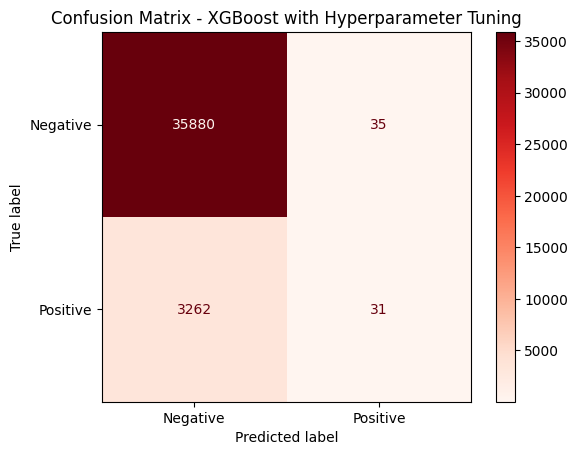

```python
from sklearn.metrics import ConfusionMatrixDisplay

for model_name, model in best_models_PCA_tuning.items():
  y_pred = model.predict(X_test_reduced)
  ConfusionMatrixDisplay.from_predictions(y_test, y_pred, display_labels=["Negative", "Positive"], cmap="Reds")
  plt.title("Confusion Matrix - XGBoost with Hyperparameter Tuning")
  plt.show()
```

```python
for model_name, model in best_models_PCA_tuning.items():
    y_pred = model.predict(X_test_reduced)
    print(f"\n{model_name} (PCA) Performance:")
    print(f"Accuracy: {accuracy_score(y_test, y_pred):.4f}")
    print(classification_report(y_test, y_pred))
    exp_name = f"XGBoost_hyperparamtune_{X_train_reduced.shape[1]}_features"
    expLog.loc[len(expLog)] = [f"{exp_name}"] + list(np.round(
                  [accuracy_score(y_train, model.predict(X_train_reduced)),
                    accuracy_score(y_valid, model.predict(X_valid_reduced)),
                    accuracy_score(y_test, model.predict(X_test_reduced)),
                    roc_auc_score(y_train, model.predict_proba(X_train_reduced)[:, 1]),
                    roc_auc_score(y_valid, model.predict_proba(X_valid_reduced)[:, 1]),
                    roc_auc_score(y_test, model.predict_proba(X_test_reduced)[:, 1]),
                    precision_score(y_train, model.predict(X_train_reduced)),
                    precision_score(y_valid, model.predict(X_valid_reduced)),
                    precision_score(y_test, model.predict(X_test_reduced)),
                    recall_score(y_train, model.predict(X_train_reduced)),
                    recall_score(y_valid, model.predict(X_valid_reduced)),
                    recall_score(y_test, model.predict(X_test_reduced)),
                    f1_score(y_train, model.predict(X_train_reduced)),
                    f1_score(y_valid, model.predict(X_valid_reduced)),
                    f1_score(y_test, model.predict(X_test_reduced)),
                    log_loss(y_train, model.predict_proba(X_train_reduced)[:, 1]),
                    log_loss(y_valid, model.predict_proba(X_valid_reduced)[:, 1]),
                    log_loss(y_test, model.predict_proba(X_test_reduced)[:, 1])],

        4))
expLog
```

```
XGBoost (PCA) Performance:
Accuracy: 0.9159
              precision    recall  f1-score   support

           0       0.92      1.00      0.96     35915
           1       0.47      0.01      0.02      3293

    accuracy                           0.92     39208
   macro avg       0.69      0.50      0.49     39208
weighted avg       0.88      0.92      0.88     39208
```

[output not shown]

[figure not shown]

```python
# Metrics to plot
metrics_to_plot = ["Valid_F1", "Test_ROC_AUC", "Valid_Accuracy"]

# Create the plot
fig, ax = plt.subplots(figsize=(12, 8))

# X-axis positions for the models
x = np.arange(len(expLog["Experiment_Name"]))

# Bar width
width = 0.25

# Plot each metric
for i, metric in enumerate(metrics_to_plot):
    ax.bar(x + i * width, expLog[metric], width, label=metric)

# Add plot details
ax.set_xlabel("Models", fontsize=12)
ax.set_ylabel("Scores", fontsize=12)
ax.set_title("Key Metrics Comparison Across Models", fontsize=14)
ax.set_xticks(x + width)
ax.set_xticklabels(expLog["Experiment_Name"], rotation=90)
ax.legend(title="Metric", fontsize=10)
ax.grid(axis="y", linestyle="--", alpha=0.7)

# Optimize layout and display the plot
plt.tight_layout()
plt.show()
```

### 7.2 Upload to Kaggle

```python
X_kaggle_test = datasets["application_test"] # Primary submission testing dataset
```

```python
merge_all_data = True

if merge_all_data:
    # 1. Transform and merge Bureau/Bureau Balance data
    bureau_aggregated = bureau_feature_pipeline.transform(bureau)
    X_kaggle_test= X_kaggle_test.merge(bureau_aggregated, how='left', on='SK_ID_CURR')
    bureau_balance_aggregated = bureau_balance_feature_pipeline.transform(bureau_balance)
    X_kaggle_test = X_kaggle_test.merge(bureau_balance_aggregated, how='left', on='SK_ID_CURR')

    # 2. Transform and merge Credit Card Balance data
    credit_card_aggregated = credit_card_feature_pipeline.transform(credit_card_balance)
    X_kaggle_test = X_kaggle_test.merge(credit_card_aggregated, how='left', on='SK_ID_CURR')

    # 3. Transform and merge Installments data
    installments_aggregated = installments_feature_pipeline.transform(installments)
    X_kaggle_test = X_kaggle_test.merge(installments_aggregated, how='left', on='SK_ID_CURR')

    # 4. Transform and merge POS Cash Balance data
    pos_cash_aggregated = pos_cash_feature_pipeline.transform(pos_cash)
    X_kaggle_test = X_kaggle_test.merge(pos_cash_aggregated, how='left', on='SK_ID_CURR')

    # 5. Transform and merge Previous Applications data
    previous_apps_aggregated = prev_apps_feature_pipeline.transform(previous_apps)
    X_kaggle_test = X_kaggle_test.merge(previous_apps_aggregated, how='left', on='SK_ID_CURR')

# Print resulting dataset shape and columns for verification
print(f"Transformed X_kaggle_test shape: {X_kaggle_test.shape}")
print(f"Columns in transformed X_kaggle_test: {X_kaggle_test.columns}")
```

```
Transformed X_kaggle_test shape: (48744, 208)
Columns in transformed X_kaggle_test: Index(['SK_ID_CURR', 'NAME_CONTRACT_TYPE', 'CODE_GENDER', 'FLAG_OWN_CAR',
       'FLAG_OWN_REALTY', 'CNT_CHILDREN', 'AMT_INCOME_TOTAL', 'AMT_CREDIT',
       'AMT_ANNUITY', 'AMT_GOODS_PRICE',
       ...
       'POS_COMPLETED_BEFORE_MEAN', 'POS_REMAINING_INSTALMENTS',
       'POS_REMAINING_INSTALMENTS_RATIO', 'AMT_ANNUITY_min_y',
       'AMT_ANNUITY_max_y', 'AMT_ANNUITY_mean_y', 'AMT_APPLICATION_min',
       'AMT_APPLICATION_max', 'AMT_APPLICATION_mean', 'range_AMT_APPLICATION'],
      dtype='object', length=208)
```

```python
final_phase_3_model = {
    "XGBoosting": XGBClassifier(random_state=42)
}
```

```python
categorical_features = X_train.select_dtypes(include=['object', 'category']).columns.tolist()
numerical_features = X_train.select_dtypes(include=['int64', 'float64']).columns.tolist()

categorical_transformer = Pipeline(steps=[
    ('target_encoder', TargetEncoder(handle_unknown='ignore'))
])

numerical_transformer = Pipeline(steps=[
    ('imputer', SimpleImputer(strategy='mean')),
    ('scaler', StandardScaler())
])

preprocessor = ColumnTransformer(
    transformers=[
        ('num', numerical_transformer, numerical_features),
        ('cat', categorical_transformer, categorical_features)
    ]
)

final_phase_3_pipelines = {}
for model_name, model in final_phase_3_model.items():
    final_phase_3_pipelines[model_name] = Pipeline(steps=[
        ('preprocessor', preprocessor),
        ('model', model)
    ])
```

```python
%%time
best_models = {}
for model_name, pipeline in final_phase_3_pipelines.items():
    print(f"Training {model_name}...")
    pipeline.fit(X_train, y_train)
    best_models[model_name] = pipeline
```

```
Training XGBoosting...
CPU times: user 41.8 s, sys: 421 ms, total: 42.2 s
Wall time: 8.54 s
```

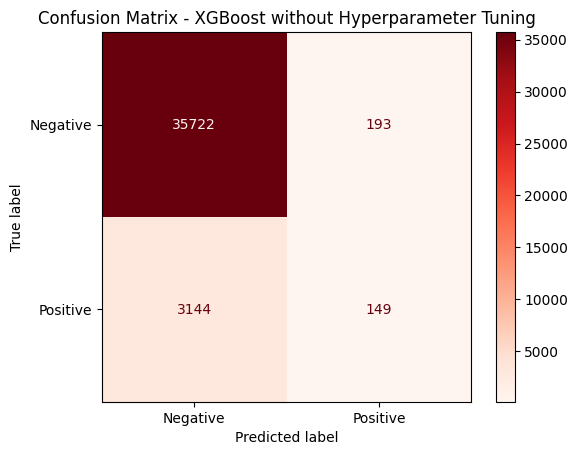

```python
from sklearn.metrics import ConfusionMatrixDisplay

for model_name, model in best_models.items():
  y_pred = model.predict(X_test)
  ConfusionMatrixDisplay.from_predictions(y_test, y_pred, display_labels=["Negative", "Positive"], cmap="Reds")
  plt.title("Confusion Matrix - XGBoost without Hyperparameter Tuning")
  plt.show()
```

```python
X_kaggle_test = X_kaggle_test.replace([np.inf, -np.inf], np.nan)
for model_name, model in best_models.items():
    test_class_scores = model.predict(X_kaggle_test)
```

```python
print(test_class_scores[0:10])
```

```
[0 0 0 0 0 0 0 0 0 0]
```

```python
test_class_scores[0:10]
```

```
array([0, 0, 0, 0, 0, 0, 0, 0, 0, 0])
```

```python
# Submission dataframe
submit_df = datasets["application_test"][['SK_ID_CURR']]
submit_df['TARGET'] = test_class_scores

submit_df.head()
```

|  | SK_ID_CURR | TARGET |
| --- | --- | --- |
| 0 | 100001 | 0 |
| 1 | 100005 | 0 |
| 2 | 100013 | 0 |
| 3 | 100028 | 0 |
| 4 | 100038 | 0 |

```python
submit_df.to_csv("submission.csv",index=False)
```

```python
! kaggle competitions submit -c home-credit-default-risk -f submission.csv -m "baseline submission"
```

```
100% 428k/428k [00:00<00:00, 1.03MB/s]
Successfully submitted to Home Credit Default Risk
```

# 8. Discussion

## 8.1 Results

```python
# Metrics to plot
metrics_to_plot = ["Valid_F1", "Test_ROC_AUC", "Valid_Accuracy"]

# Create the plot
fig, ax = plt.subplots(figsize=(12, 6))

# X-axis positions for the models
x = np.arange(len(expLog["Experiment_Name"]))

# Bar width
width = 0.25

# Plot each metric
for i, metric in enumerate(metrics_to_plot):
    ax.bar(x + i * width, expLog[metric], width, label=metric)

# Add plot details
ax.set_xlabel("Models", fontsize=12)
ax.set_ylabel("Scores", fontsize=12)
ax.set_title("Key Metrics Comparison Across Models", fontsize=14)
ax.set_xticks(x + width)
ax.set_xticklabels(expLog["Experiment_Name"], rotation=45)
ax.legend(title="Metric", fontsize=10)
ax.grid(axis="y", linestyle="--", alpha=0.7)

# Optimize layout and display the plot
plt.tight_layout()
plt.show()
```

[output not shown]

The confusion matrix for XGBoost demonstrates that while the model correctly identified the majority of negative samples, it performed poorly in predicting positive samples, further emphasizing the impact of imbalance on performance. Future efforts will focus on improving recall for the minority class through techniques such as oversampling, undersampling, or advanced ensemble strategies.

In summary, while XGBoost delivered strong overall accuracy, the performance metrics for the minority class indicate the need for further refinement. Moving forward, we will prioritize addressing class imbalance and exploring alternative approaches to improve minority class predictions.

## 8.2 Gap Analysis

**Comparison with other groups:** Despite a humble public AUC score, our team demonstrated the **strongest test AUC score** in this Phase, showcasing the effectiveness of our XGBoost model. We can learn from Group 3 (who performed KNeighbors) for handling of data despite longer training times, as well as from Group 7 (with 747 features) for better performance. Our **efficient training time** (8.54 seconds) stands out as a strength, allowing for quicker iterations. However, we can improve by refining our feature selection process to avoid overfitting, as seen in the best performing models. Adapting their feature selection and model refinement strategies could further enhance our results.

## 8.3 Challenges

The high dimensionality of the dataset further complicated the dimensionality reduction process, as PCA alone was insufficient to simplify the dataset effectively. The severe imbalance in the target variable also hindered model performance, resulting in low recall and F1-scores for the minority class. Collaborative work added another layer of complexity, as multiple people editing the same file led to version control issues.

Looking forward to Phase 4, we plan to implement and experiment with neural networks to improve efficiency and accuracy. Incorporating adjustments and insights gained from Phase 3 will help address these challenges and optimize our modeling workflow moving forward.

# 9. Conclusion

# 10. Biography

- LogisticRegression Documentation. https://scikit-learn.org/dev/modules/linear_model.html
- SVC Documentation. https://scikit-learn.org/dev/modules/svm.html
- DecisionTreeClassifier Documentation. https://scikit-learn.org/dev/modules/generated/sklearn.tree.DecisionTreeClassifier.html
- RandomForestClassifier Documentation. https://scikit-learn.org/1.5/modules/generated/sklearn.ensemble.RandomForestClassifier.html
- GradientBoostingClassifier Documentation. https://scikit-learn.org/dev/modules/generated/sklearn.ensemble.GradientBoostingClassifier.html
- LightGBM Documentation. https://lightgbm.readthedocs.io/en/latest/Parameters.html
- Beginner’s Guide to the Must-Know LightGBM Hyperparameters. (Medium article) https://towardsdatascience.com/beginners-guide-to-the-must-know-lightgbm-hyperparameters-a0005a812702
- XGBoost Documentation. https://xgboost.readthedocs.io/en/stable/parameter.html
- VotingClassifier documentation. https://scikit-learn.org/0.18/modules/generated/sklearn.ensemble.VotingClassifier.html
- StackingClassifier documentation. https://scikit-learn.org/dev/modules/generated/sklearn.ensemble.StackingClassifier.html